# Stat 11 Week 10

Review of Unit 2

Prof. Suzy Thornton

# Unit 2 topics

- Collecting data
- Randomness and probability

# Collecting data from experiments and observational studies

- Sample surveys
- Sampling bias
- Experiments and observational studies

Q1) What role does randomness play in both observational studies and experiments?

Q2) What role does randomness play in experiments alone?

# From randomness to probability and the laws of probability

- Random variables - Bernoulli, binomial, and normal
  - Expectation, variance, and their properties
  - Independent categorical variables
- Probability rules
  - Independent events
  - Disjoint events
  - Conditional probabilities
    - tree diagrams
      - A tree diagram is most helpful when a problem seems to be describing a conditional probability.
      - In a tree diagram, all branches extending from the same node must add to 1.
      - At end end of a tree diagram, all outcomes at the far right should be disjoint (i.e. it should not be possible for any of these outcomes to occur simultaneously) and their probabilities should also sum to 1.

## Example - Binomial probabilities

Suppose we are considering a random event that can be modeled as a series of independent successes or failures. Let’s say the probability of a success is $0.3$ and the probability of a failure is $0.7$. Find the following probabilities:

1. The probability of observing three successes (in a row).
2. The probability of observing three successes out of $10$ trials.

## Example - calculate $E(X)$, $Var(X)$, and $sd(X)$

Suppose we have a discrete random variable $X$ with the following probability distribution:

| x | 23 | -14 | 75 | 0 |
| --- | --- | --- | --- | --- |
| Pr(X=x) | 0.20 | 0.10 | 0.15 | 0.50 |

- $E(X) = \sum_{x}[x \cdot Pr(X=x)]$
- $Var(X) = \sum_{x}\{[x-E(X)]^2 \cdot Pr(X=x)\}$
- $sd(X) = \sqrt{Var(X)}$

### Example - Tree diagram

A Diner employs three dishwashers. Al washes $40\%$ of the dishes and breaks only $1\%$ of those he handles. Betty and Chuck each wash $30\%$ of the dishes and Better breaks only $1\%$ of hers, but Chuck breaks $3\%$ of the dishes he washes.

You’re eating at the diner one night and hear a dish break in the kitchen. What’s the probability that Chuck is on the job?

### Example - Venn diagram

Suppose the probability that a US resident has traveled to Canada is $0.18$ and the probability that a US resident has traveled to Mexico is $0.09$. If probability that a US resident has traveled to both countries is $0.04$, then calculate the following probabilities that a randomly selected US resident has:

1. traveled to Canada but not Mexico?
2. traveled to either Canada or Mexico?
3. not traveled to either country?

### Example - Contingency table

A company’s human resources officer reports a breakdown of employees by job type and gender as show in the table below.

|  | Woman | Man |
| --- | --- | --- |
| Management | 6 | 7 |
| Supervision | 12 | 8 |
| Production | 72 | 45 |

What is the probability that a worker selected at random is:

1. a woman?
2. a woman or a production worker?
3. a woman if the person works in production?
4. a production worker if the person is a woman?

Do these data suggest that job type is independent of gender?

# Solutions to the exercises above

## Binomial probabilities

1. The probability of observing three successes (in a row) is $0.3^3$.
2. The probability of observing three successes out of $10$ trials is $10C3 \cdot 0.3^3 \cdot (1-0.3)^7$.

## Tree diagram

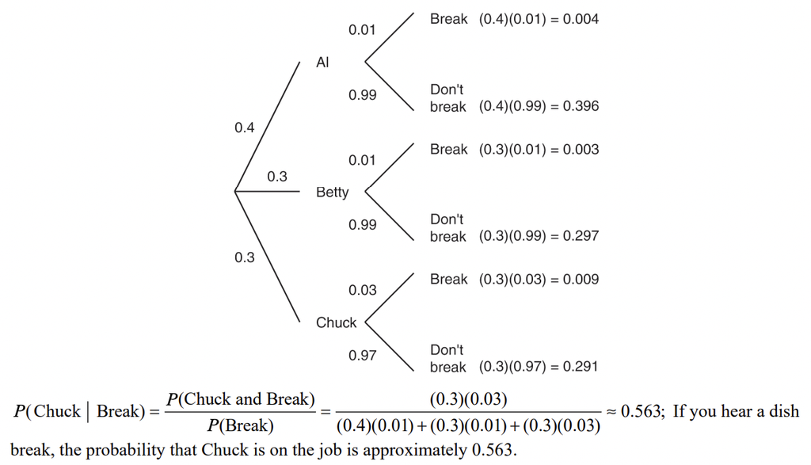